# Resume

### Resume

#### Project lists

- 水文（低质文本）甄别
  - 从数据库获取待识别的新闻资源的信息
  - 确定所述待识别的新闻资源低质与优质标准
    - 质量低：人工审核驳回文章
    - 质量高：利用现有特征 **positive** 值（分享量/优质评论/点赞数）
    - 水文特点：无中心思想，不知所云，随意堆砌文字和图片，全文仅仅几张配图几句话，甚至图片为P的（视频截图），看图说话无看点，可能伴随着胡编乱造、语义不通等现象。
  - 文本预处理（去除正样本中的短于特定字数的文章/xml中正则提取正文/分词）
  - 以词粒度，进行fasttext文本分类并调参优化
- [用户行为相似度](https://github.com/WeifanD/fireeye)
  - 根据师傅间行为的相似性，自动识别出前一天有刷金币嫌疑的用户团伙
- [fireeye反作弊数据功能](https://github.com/WeifanD/fireeye)

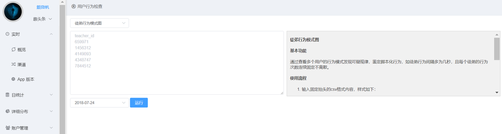

- [可疑行为图像自动化识别](https://github.com/WeifanD/Behavior-Classification)
- 图数据库（关系网络）
- 沃尔玛节假日销售预测
  - 沃尔玛销售预测，对于时间序列模型要进行CV不能用普通的方法 split based on target distribution, 用K+i个做为验证，前K+i−1个作为训练集 .
- 零售门店缺货预警
  - Worked with **reducing the false positives in the out of shelf detection algorithm** by applying various classification algorithms like decision tree, random forest and gradient boosting. Clustered the stores to help improve the detection performance. The machine learning results guided and improved the out-of-stock alerting software application, which created significant value in our clients’ businesses.
- 用户论坛数据舆情处理
  - 利用爬虫工具爬取数据，并进行数据预处理操作
  - 构建情感倾向性模型对评论进行分类
  - 基于语义网络的评论分析，以进行语意网络的构建与分析。
  - 基于 LDA 模型的主题分析发现潜在的主题
- 反欺诈交易识别
- 犯罪物证的来源追溯
  - 主要探究的是车祸犯罪现场残留物质的原始物件来源的探索，也就是说比如地上一小片车漆或灯泡碎片我们通过光谱技术把物质的化学成分转化成光谱数据，结合机器学习算法，通过数据找到对应犯罪车辆。
  - 对于特别宽的数据集，数据的每一行是一个样本对应的spectrum光谱，每一列是光谱中各段波长所对应的吸收或反射值。所以总体来说此数据集有两个显著特点，高维高度线性相关的宽数据，但优势是没有缺失值异常值。
- 反欺诈评分卡：
  - 量化评测车主驾车安全的数据产品,对每个车主有一个综合打分的评分机制,我们内部称作okscore。基于其专利车联网技术，以车主的用车安全为核心的多维度、通过立体评测产生的保险分数产品，将培养良好驾驶习惯落实到车主的每次驾驶行为中。我们的评分体系主要参考美国的征信巨头FICO，结合我们内部技术所有的数据，分为
  - 个人身份特质（隐私）
  - 个人信用历史（征信信用历史与履约能力）
  - 个人消费习惯
  - 人与车（OKdrive）
  - 人与人（朋友圈）

#### Others

- Azkaban自动化流任务
- 用于社群查询的ShinyApp
- 利用tableau完成用户可疑特征的storyline

持续更新中…